# PS1

Xiuqi Ning (12173771)

2018-10-07

**Front matter**

This submission is my work alone and complies with the 30531 integrity policy.

Add your initials to indicate your agreement: **__**

# 1 Setup

# 2 R4DS Exercises

2.1.1 I think nothing is displayed, because in this case, neither the mapping and the geom is specified.

2.1.2

```r
library(tidyverse)
dim(mpg)
```

```
## [1] 234  11
```

There are 234 rows 11 columns. The rows represent observations, and the columns represent variables.

2.1.3

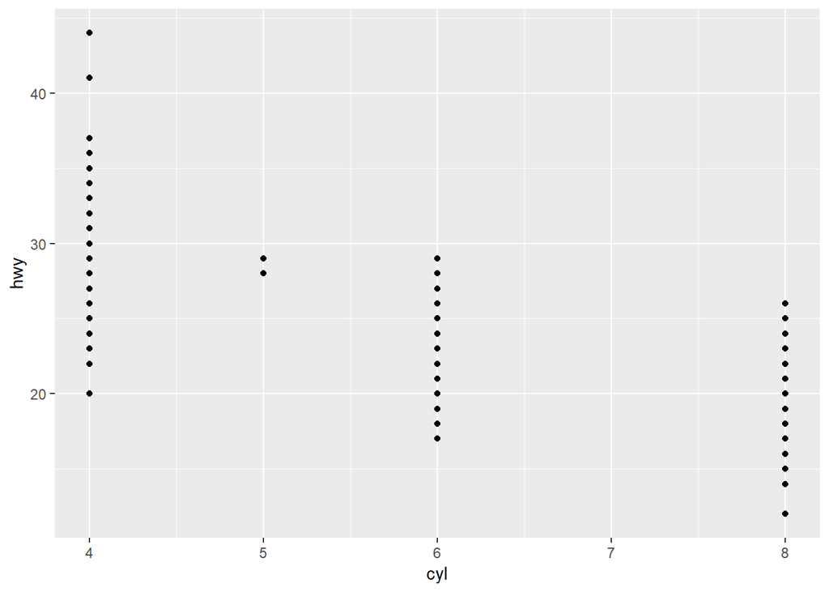

```r
mpg <- ggplot2::mpg
ggplot(data=mpg)+
  geom_point(mapping=aes(x=cyl,y=hwy))
```

2.1.4

```r
?mpg
```

f =front-wheel drive, r=rear wheel drive, 4=4wd

2.1.5

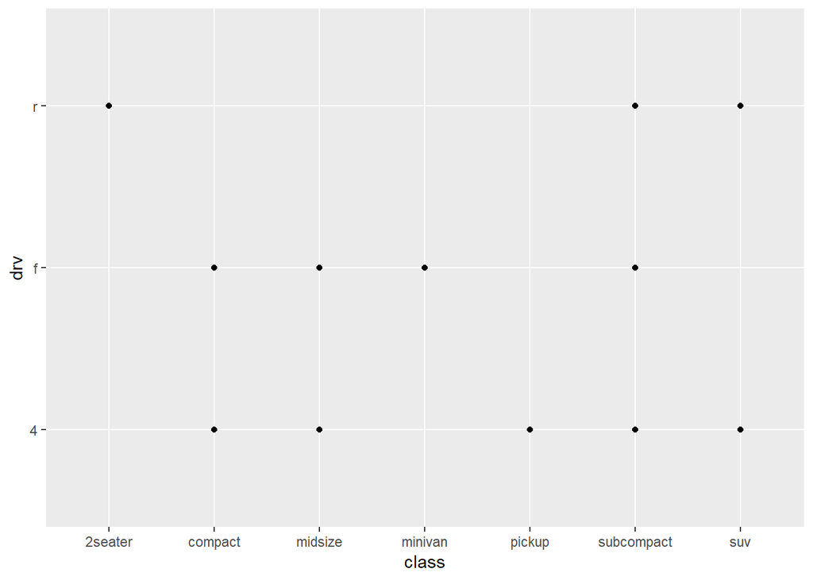

```r
ggplot(data=mpg)+
  geom_point(mapping=aes(x=class,y=drv))
```

Because in this dataset, both class and drv are categorical variables. The only information this scatter plot reveals is what combinations of class and drv exist in the dataset. For example, there are front-wheel drive compact vehicles, but no front-wheel drive 2 seaters.

2.2.1

```r
?mpg
print(mpg)
```

```
## # A tibble: 234 x 11
##    manufacturer model displ  year   cyl trans drv     cty   hwy fl    cla~
##    <chr>        <chr> <dbl> <int> <int> <chr> <chr> <int> <int> <chr> <ch>
##  1 audi         a4      1.8  1999     4 auto~ f        18    29 p     com~
##  2 audi         a4      1.8  1999     4 manu~ f        21    29 p     com~
##  3 audi         a4      2    2008     4 manu~ f        20    31 p     com~
##  4 audi         a4      2    2008     4 auto~ f        21    30 p     com~
##  5 audi         a4      2.8  1999     6 auto~ f        16    26 p     com~
##  6 audi         a4      2.8  1999     6 manu~ f        18    26 p     com~
##  7 audi         a4      3.1  2008     6 auto~ f        18    27 p     com~
##  8 audi         a4 q~   1.8  1999     4 manu~ 4        18    26 p     com~
##  9 audi         a4 q~   1.8  1999     4 auto~ 4        16    25 p     com~
## 10 audi         a4 q~   2    2008     4 manu~ 4        20    28 p     com~
## # ... with 224 more rows
```

2.2.2 Gragh 1:

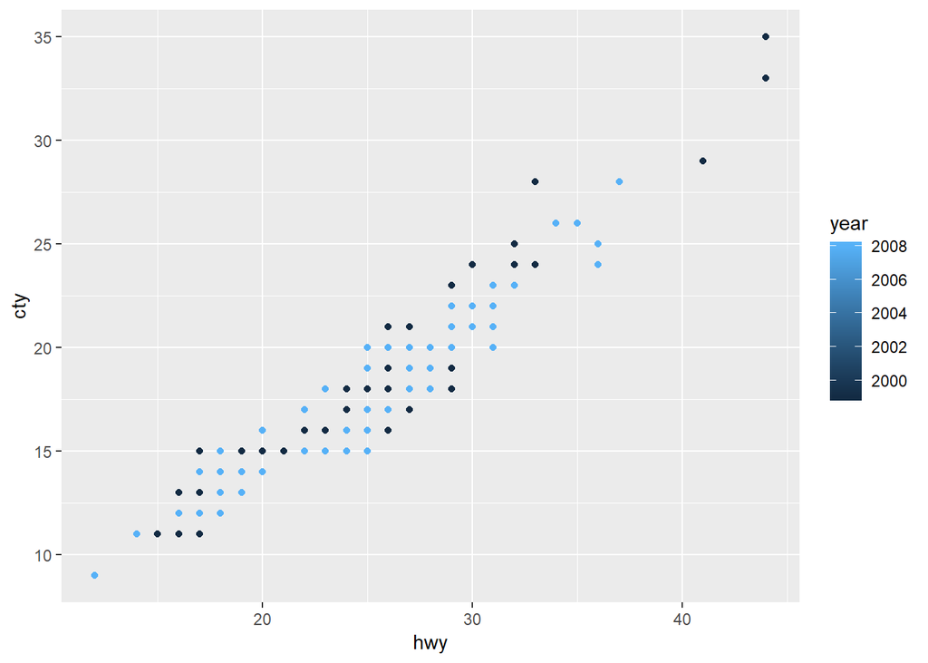

```r
ggplot(data=mpg)+
  geom_point(mapping=aes(x=hwy,y=cty,color=year))
```

Graph 2:

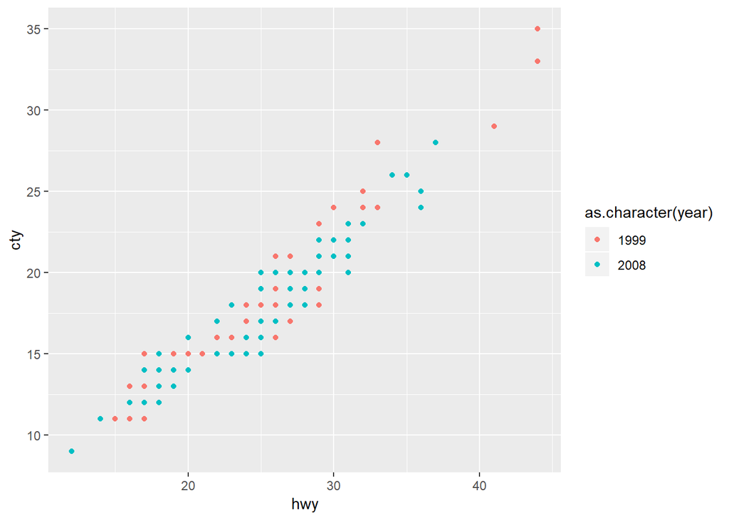

```r
ggplot(data=mpg)+
  geom_point(mapping=aes(x=hwy,y=cty,color=as.character(year)))
```

I think the second graph is better, because it seems more straightforward than the first one.

2.2.4

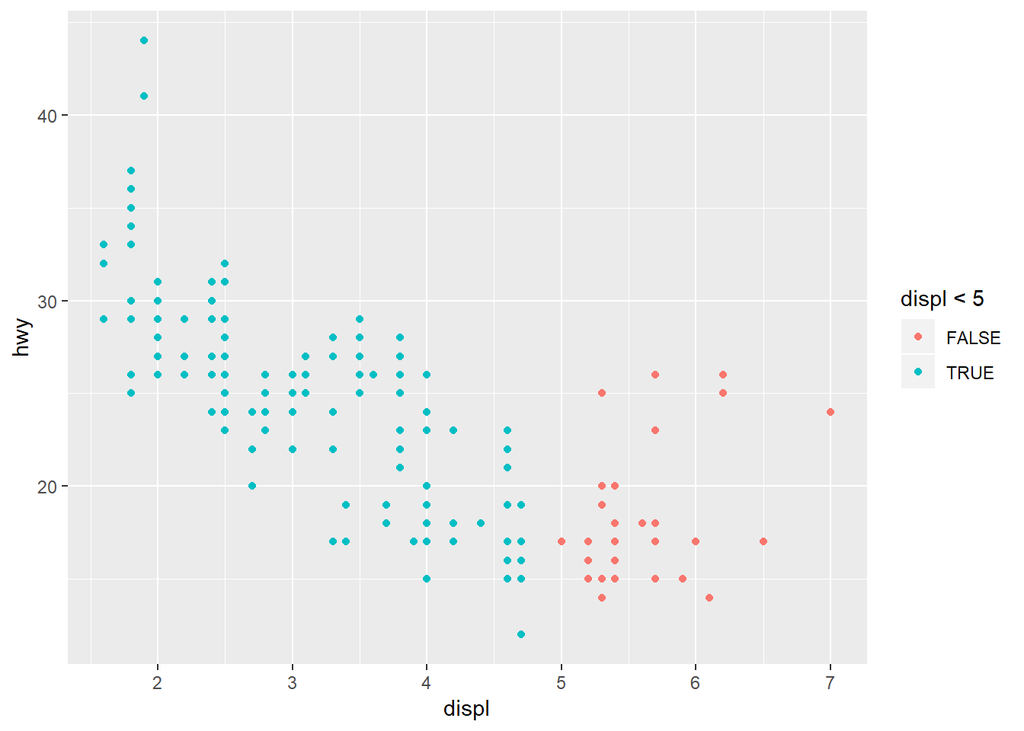

```r
ggplot(data=mpg)+
  geom_point(mapping=aes(x=displ,y=hwy,color=displ<5))
```

As shown in the above scatter plots, ggplot evaluates displ < 5 and creates a temporary boolean variable indicating whether the observations satisfy the specified condition, and represents TRUE and FALSE with different colors.

2.2.5

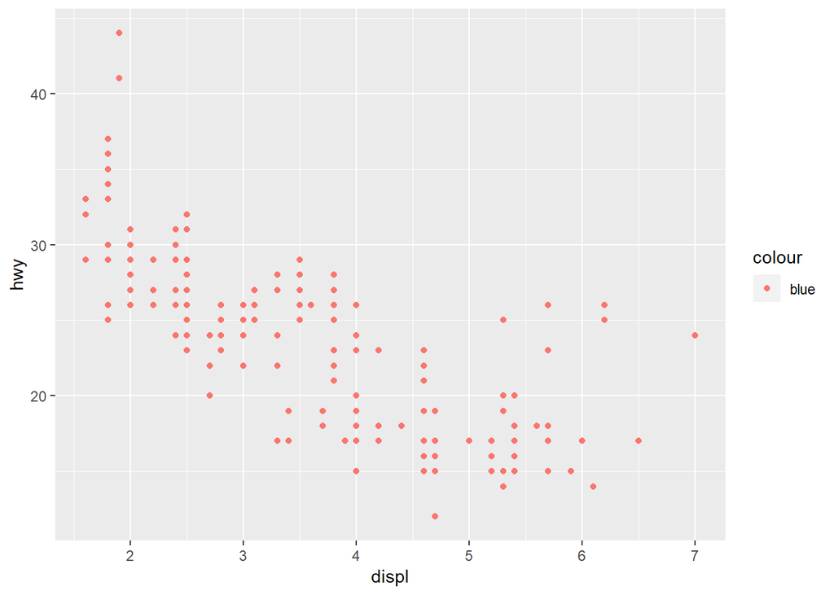

```r
ggplot(data=mpg)+
  geom_point(mapping=aes(x=displ,y=hwy,color="blue"))
```

I think the problem is that when “blue” is assigned to the color of ggplot, it should not be put inside the function aes().